# Wilt Data

2022-10-06

**Sources**

https://archive.ics.uci.edu/ml/datasets/wilt

Brian Johnson; Institute for Global Environmental Strategies; 2108-11 Kamiyamaguchi, Hayama, Kanagawa,240-0115 Japan; Email: Johnson ‘@’ iges.or.jp

**About**

This data set contains data from a remote sensing study by Johnson et al. (2013) that involved detecting diseased trees in Quickbird imagery.The data set consists of image segments, generated by segmenting the pansharpened image. The segments contain spectral information from the Quickbird multispectral image bands and texture information from the panchromatic (Pan) image band.

**Attribute Information:**

1. class: ‘w’ (diseased trees), ‘n’ (all other land cover)
2. GLCM_Pan: GLCM mean texture (Pan band)
3. Mean_Green: Mean green value
4. Mean_Red: Mean red value
5. Mean_NIR: Mean NIR value
6. SD_Pan: Standard deviation (Pan band)

**Citation Request:**

Johnson, B., Tateishi, R., Hoan, N., 2013. A hybrid pansharpening approach and multiscale object-based image analysis for mapping diseased pine and oak trees. International Journal of Remote Sensing, 34 (20), 6969-6982.

## Attributes Details

```r
library(readxl)
library(moments)

wilt <- read_xlsx("Wilt_Dataset.xlsx")
class0 <- subset(wilt,class=='w')
class1<-subset(wilt,class=='n')
options(digits = 2)
summary(wilt)
```

```
##     class              GLCM_pan     Mean_Green     Mean_Red      Mean_NIR
##  Length:4339        Min.   :  0   Min.   :165   Min.   : 59   Min.   :  86
##  Class :character   1st Qu.:119   1st Qu.:206   1st Qu.: 92   1st Qu.: 423
##  Mode  :character   Median :127   Median :221   Median :102   Median : 528
##                     Mean   :127   Mean   :234   Mean   :117   Mean   : 534
##                     3rd Qu.:135   3rd Qu.:242   3rd Qu.:117   3rd Qu.: 643
##                     Max.   :183   Max.   :956   Max.   :746   Max.   :1006
##      SD_pan
##  Min.   :  0
##  1st Qu.: 18
##  Median : 24
##  Mean   : 25
##  3rd Qu.: 30
##  Max.   :157
```

**1) GLCM_Pan**

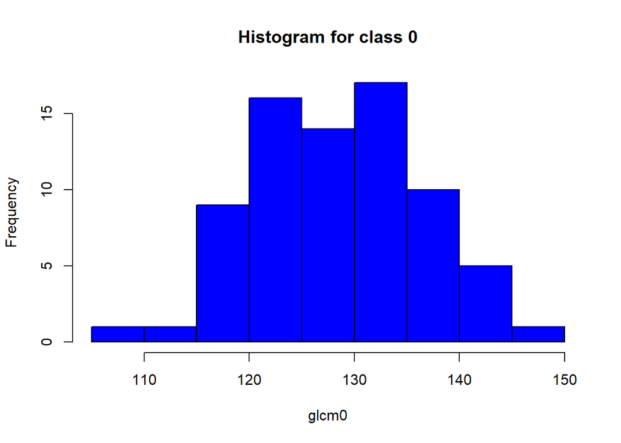

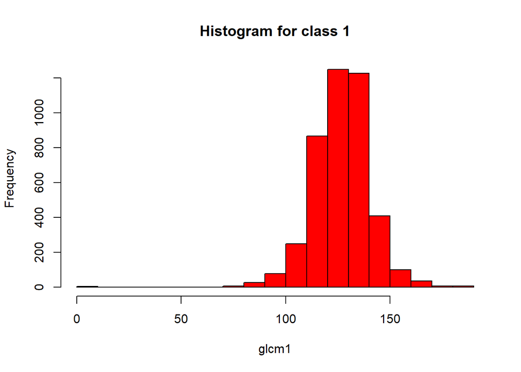

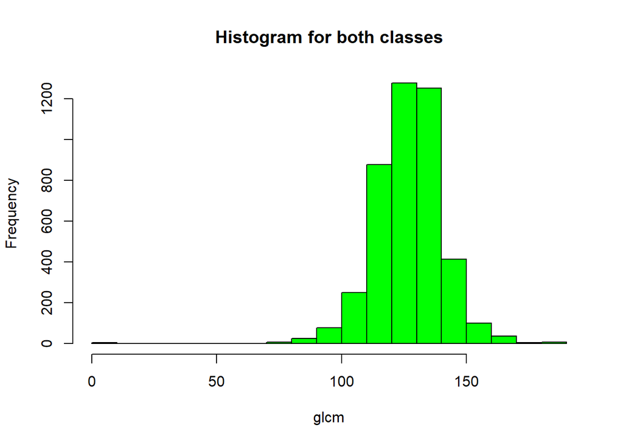

```r
glcm0<-class0$GLCM_pan
hist(glcm0, main= "Histogram for class 0", col = "blue")
glcm1<-class1$GLCM_pan
hist(glcm1, main= "Histogram for class 1", col = "red")
glcm<-wilt$GLCM_pan
hist(glcm, main= "Histogram for both classes", col = "green")
```

**2) Green**

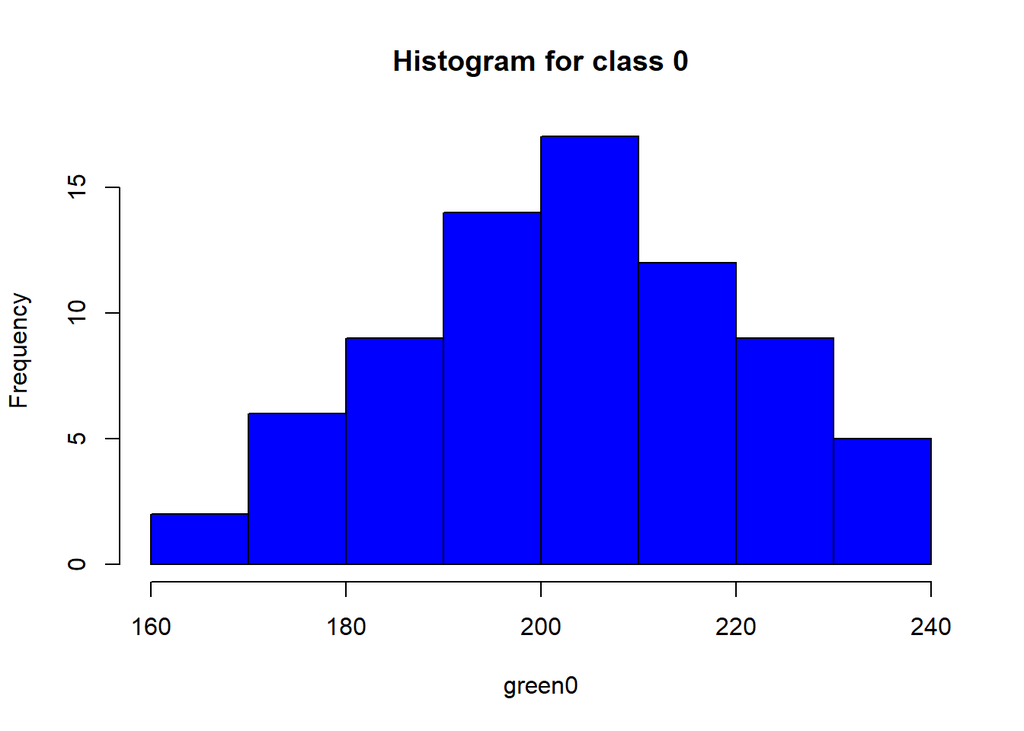

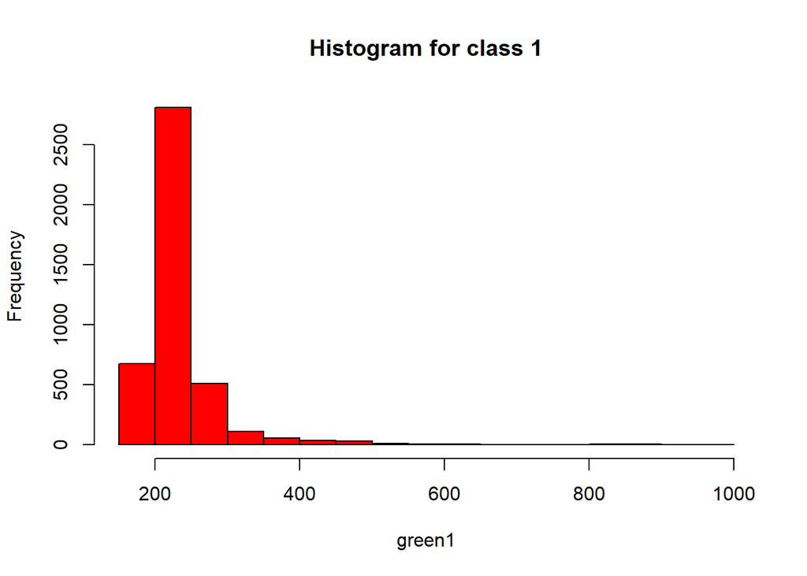

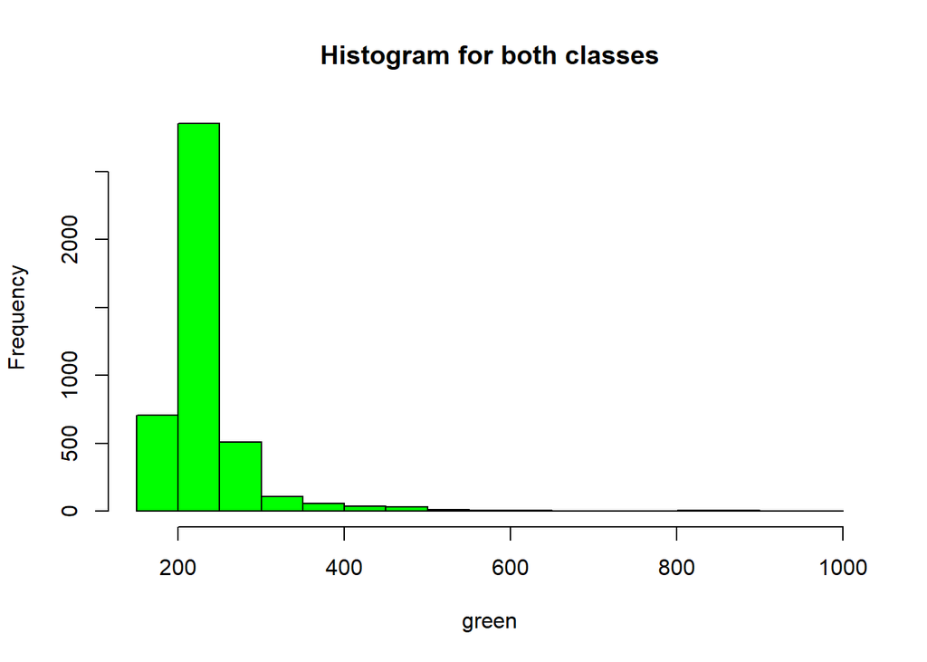

```r
green0<-class0$Mean_Green
hist(green0, main= "Histogram for class 0", col = "blue")
green1<-class1$Mean_Green
hist(green1, main= "Histogram for class 1", col = "red")
green<-wilt$Mean_Green
hist(green, main= "Histogram for both classes", col = "green")
```

**3) Red**

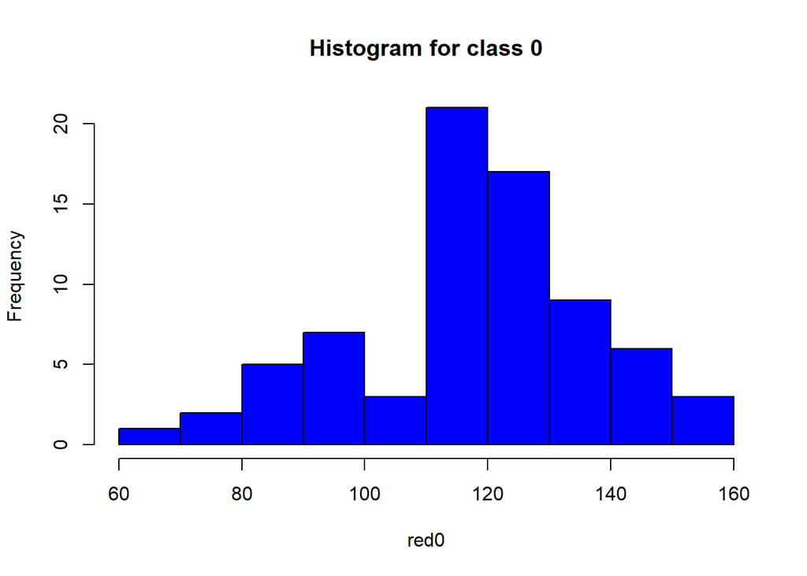

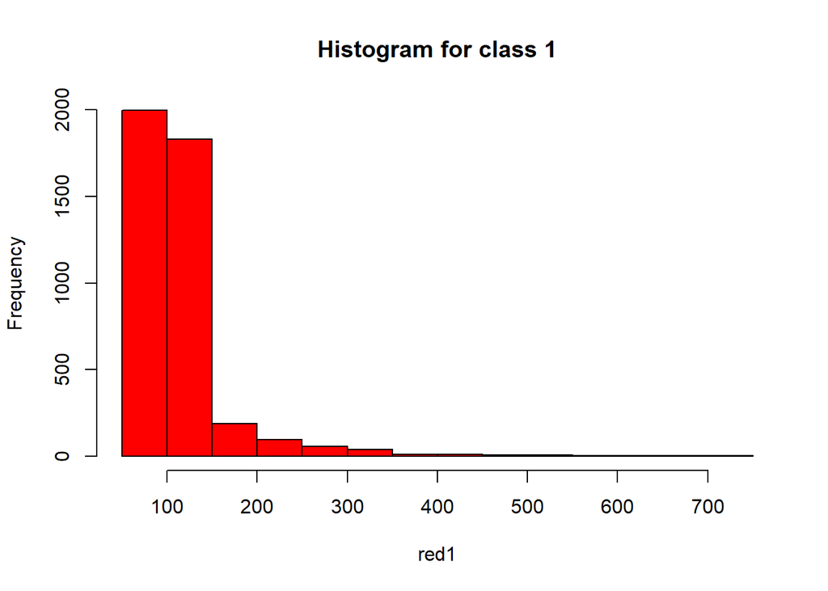

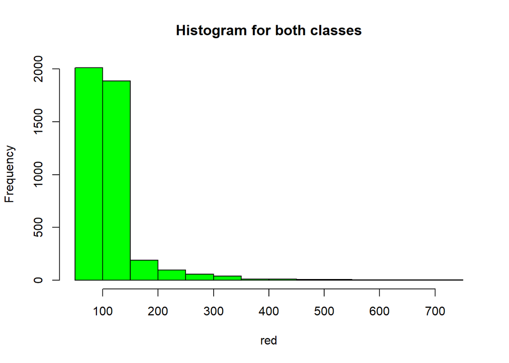

```r
red0<-class0$Mean_Red
hist(red0, main= "Histogram for class 0", col = "blue")
red1<-class1$Mean_Red
hist(red1, main= "Histogram for class 1", col = "red")
red<-wilt$Mean_Red
hist(red, main= "Histogram for both classes", col = "green")
```

**4) NIR**

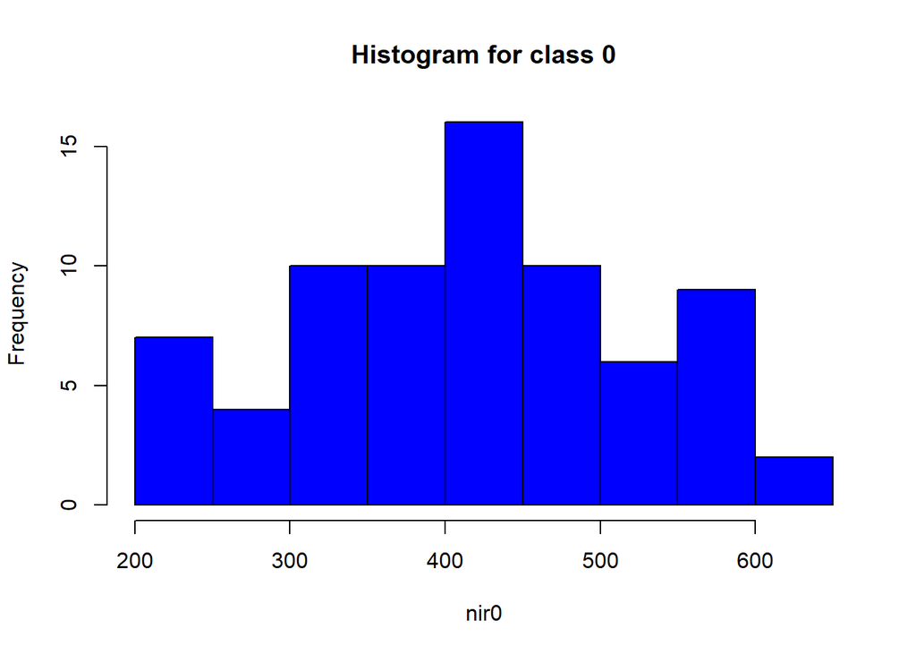

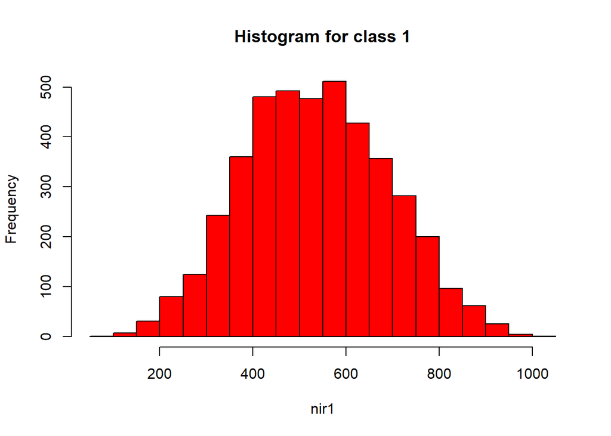

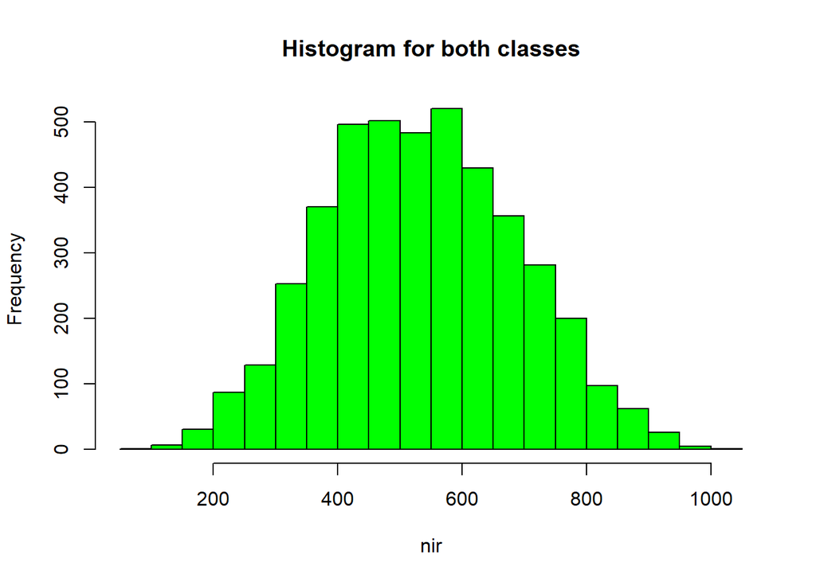

```r
nir0<-class0$Mean_NIR
hist(nir0, main= "Histogram for class 0", col = "blue")
nir1<-class1$Mean_NIR
hist(nir1, main= "Histogram for class 1", col = "red")
nir<-wilt$Mean_NIR
hist(nir, main= "Histogram for both classes", col = "green")
```

**5) Pan**

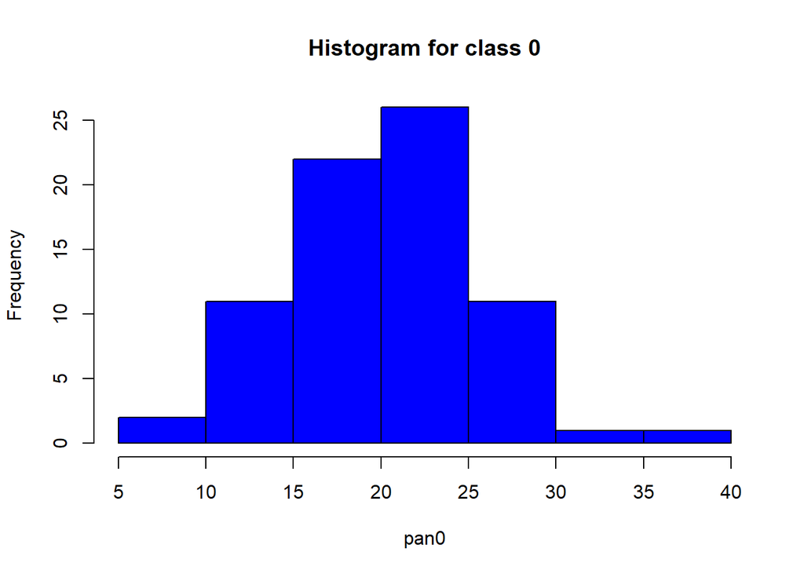

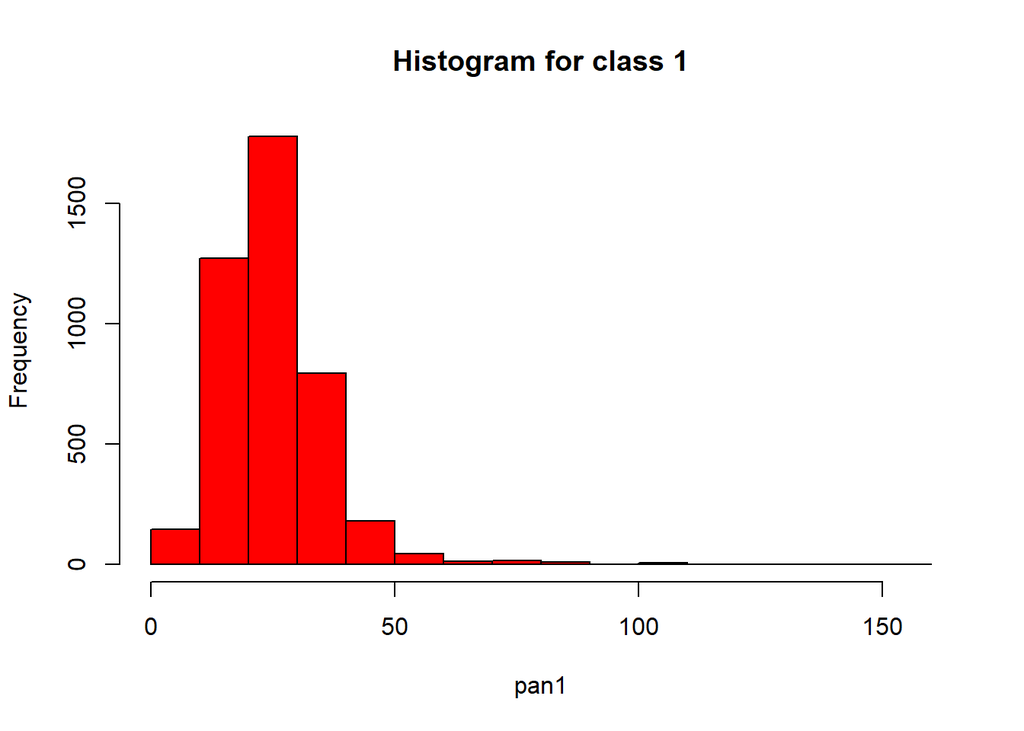

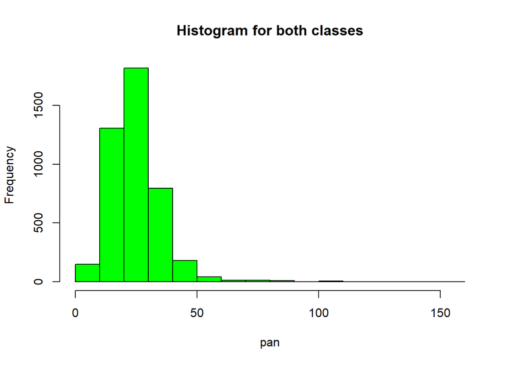

```r
pan0<-class0$SD_pan
hist(pan0, main= "Histogram for class 0", col = "blue")
pan1<-class1$SD_pan
hist(pan1, main= "Histogram for class 1", col = "red")
pan<-wilt$SD_pan
hist(pan, main= "Histogram for both classes", col = "green")
```

## Correlation Matrix

**Class 0**

```r
options(digits = 2)
cor(class0[-1])
```

```
##            GLCM_pan Mean_Green Mean_Red Mean_NIR SD_pan
## GLCM_pan      1.000      -0.31    -0.40   -0.079  -0.30
## Mean_Green   -0.308       1.00     0.93    0.793   0.50
## Mean_Red     -0.396       0.93     1.00    0.664   0.50
## Mean_NIR     -0.079       0.79     0.66    1.000   0.58
## SD_pan       -0.302       0.50     0.50    0.584   1.00
```

```r
det(cor(class0[-1]))
```

```
## [1] 0.019
```

**Class 1**

```r
options(digits = 2)
cor(class1[-1])
```

```
##            GLCM_pan Mean_Green Mean_Red Mean_NIR SD_pan
## GLCM_pan      1.000      -0.12    -0.11   -0.093 -0.063
## Mean_Green   -0.121       1.00     0.97    0.217  0.243
## Mean_Red     -0.106       0.97     1.00    0.120  0.254
## Mean_NIR     -0.093       0.22     0.12    1.000  0.113
## SD_pan       -0.063       0.24     0.25    0.113  1.000
```

```r
det(cor(class1[-1]))
```

```
## [1] 0.049
```

**Both Classes**

```r
options(digits = 2)
cor(wilt[-1])
```

```
##            GLCM_pan Mean_Green Mean_Red Mean_NIR SD_pan
## GLCM_pan      1.000      -0.12    -0.11   -0.094 -0.065
## Mean_Green   -0.122       1.00     0.96    0.224  0.246
## Mean_Red     -0.107       0.96     1.00    0.121  0.254
## Mean_NIR     -0.094       0.22     0.12    1.000  0.120
## SD_pan       -0.065       0.25     0.25    0.120  1.000
```

```r
det(cor(wilt[-1]))
```

```
## [1] 0.052
```

## Correlation Matrix

**Class 0**

```r
options(digits = 2)
cor(class0[-1])
```

```
##            GLCM_pan Mean_Green Mean_Red Mean_NIR SD_pan
## GLCM_pan      1.000      -0.31    -0.40   -0.079  -0.30
## Mean_Green   -0.308       1.00     0.93    0.793   0.50
## Mean_Red     -0.396       0.93     1.00    0.664   0.50
## Mean_NIR     -0.079       0.79     0.66    1.000   0.58
## SD_pan       -0.302       0.50     0.50    0.584   1.00
```

```r
cov(class0[-1])
```

```
##            GLCM_pan Mean_Green Mean_Red Mean_NIR SD_pan
## GLCM_pan         59        -40      -59      -65    -13
## Mean_Green      -40        289      307     1456     48
## Mean_Red        -59        307      375     1389     54
## Mean_NIR        -65       1456     1389    11673    357
## SD_pan          -13         48       54      357     32
```

```r
det(cor(class0[-1]))
```

```
## [1] 0.019
```

```r
det(cov(class0[-1]))
```

```
## [1] 4.4e+10
```

```r
eigen(cor(class0[-1]))
```

```
## eigen() decomposition
## $values
## [1] 3.150 0.950 0.620 0.237 0.042
##
## $vectors
##       [,1]   [,2]   [,3]  [,4]    [,5]
## [1,]  0.25  0.907  0.019 -0.34  0.0051
## [2,] -0.53  0.113 -0.346 -0.11 -0.7572
## [3,] -0.52 -0.035 -0.378 -0.48  0.6003
## [4,] -0.47  0.403  0.075  0.74  0.2495
## [5,] -0.41 -0.026  0.855 -0.31 -0.0631
```

```r
eigen(cov(class0[-1]))
```

```
## eigen() decomposition
## $values
## [1] 12040   307    47    19    13
##
## $vectors
##         [,1]   [,2]   [,3]   [,4]   [,5]
## [1,]  0.0064  0.233  0.920 -0.311  0.056
## [2,] -0.1253 -0.536  0.217  0.368  0.717
## [3,] -0.1207 -0.793  0.134 -0.292 -0.504
## [4,] -0.9843  0.168 -0.029  0.012 -0.044
## [5,] -0.0303 -0.044 -0.297 -0.826  0.476
```

**Class 1**

```r
options(digits = 2)
cor(class1[-1])
```

```
##            GLCM_pan Mean_Green Mean_Red Mean_NIR SD_pan
## GLCM_pan      1.000      -0.12    -0.11   -0.093 -0.063
## Mean_Green   -0.121       1.00     0.97    0.217  0.243
## Mean_Red     -0.106       0.97     1.00    0.120  0.254
## Mean_NIR     -0.093       0.22     0.12    1.000  0.113
## SD_pan       -0.063       0.24     0.25    0.113  1.000
```

```r
cov(class1[-1])
```

```
##            GLCM_pan Mean_Green Mean_Red Mean_NIR SD_pan
## GLCM_pan      190.9       -102      -90     -199   -9.6
## Mean_Green   -102.2       3734     3615     2046  164.1
## Mean_Red      -89.9       3615     3743     1135  172.1
## Mean_NIR     -198.6       2046     1135    23844  192.6
## SD_pan         -9.6        164      172      193  122.4
```

```r
det(cor(class1[-1]))
```

```
## [1] 0.049
```

```r
det(cov(class1[-1]))
```

```
## [1] 3.8e+14
```

```r
eigen(cor(class1[-1]))
```

```
## eigen() decomposition
## $values
## [1] 2.172 1.016 0.914 0.870 0.028
##
## $vectors
##       [,1]  [,2]  [,3]  [,4]    [,5]
## [1,]  0.16  0.73  0.64 -0.17  0.0057
## [2,] -0.65  0.19 -0.11 -0.17  0.7099
## [3,] -0.64  0.26 -0.16 -0.10 -0.7003
## [4,] -0.23 -0.59  0.61 -0.48 -0.0730
## [5,] -0.30 -0.11  0.44  0.84  0.0147
```

```r
eigen(cov(class1[-1]))
```

```
## eigen() decomposition
## $values
## [1] 24166  7062   188   119    99
##
## $vectors
##         [,1]   [,2]    [,3]   [,4]   [,5]
## [1,]  0.0090  0.016  0.9973  0.020  0.068
## [2,] -0.1126 -0.691 -0.0206 -0.396  0.594
## [3,] -0.0751 -0.710  0.0461  0.352 -0.604
## [4,] -0.9907  0.133  0.0084  0.011 -0.026
## [5,] -0.0092 -0.030 -0.0527  0.848  0.526
```

**Both Classes**

```r
options(digits = 2)
cor(wilt[-1])
```

```
##            GLCM_pan Mean_Green Mean_Red Mean_NIR SD_pan
## GLCM_pan      1.000      -0.12    -0.11   -0.094 -0.065
## Mean_Green   -0.122       1.00     0.96    0.224  0.246
## Mean_Red     -0.107       0.96     1.00    0.121  0.254
## Mean_NIR     -0.094       0.22     0.12    1.000  0.120
## SD_pan       -0.065       0.25     0.25    0.120  1.000
```

```r
det(cor(wilt[-1]))
```

```
## [1] 0.052
```

```r
det(cov(wilt[-1]))
```

```
## [1] 3.8e+14
```

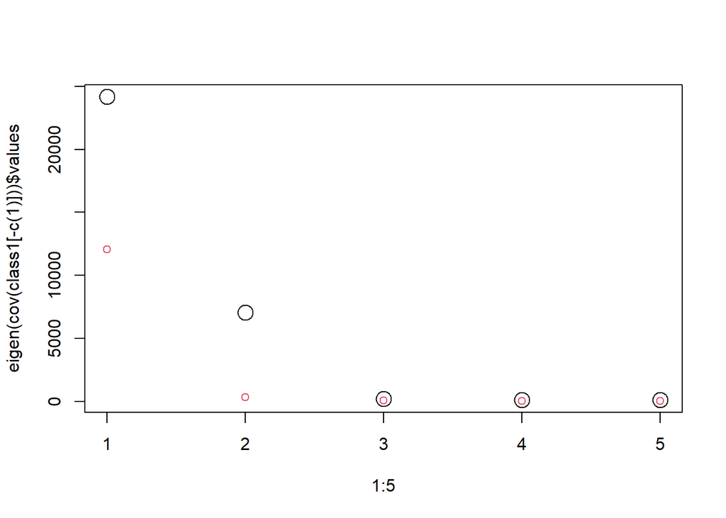

```r
plot(1:5, eigen(cov(class1[-c(1)]))$values, cex=2)
points(1:5, eigen(cov(class0[-c(1)]))$values, col=2)
```